# Problem Set 6

Author

Jialiang Wu

For source files and data, see my GitHub repo: [STATS-506-Problem-Sets-06](https://github.com/CrispyShyYi/STATS-506-Problem-Sets/tree/main/set-6)

## Problem 1

Set up

```r
# load library
library(Rcpp)
library(e1071)
```

### C_moment Function

```r
# C_moment function
cppFunction('
double C_moment(NumericVector x, int k) {

    int n = x.size();
    double mean = 0.0;

    // compute mean
    for (int i = 0; i < n; i++) {
        mean += x[i];
    }
    mean /= n;

    // compute central moment
    double moment = 0.0;
    for (int i = 0; i < n; i++) {
        moment += pow(x[i] - mean, k);
    }

    // divide by n
    return moment / n;
}
')
```

### Test

```r
set.seed(1)
x <- rnorm(100)
k <- 4

C_moment(x, k)
```

```
[1] 1.918621
```

```r
moment(x, order = k, center = TRUE)
```

```
[1] 1.918621
```

## Problem 2

### problem 2-a

```r
# `waldCI` from solution
setClass("waldCI",
         slots = c(level = "numeric", mean = "numeric", sterr = "numeric")
         )

# inherit `waldCI`
setClass(
  "bootstrapWaldCI",
  contains = "waldCI",
  slots = c(
    data = "ANY",
    FUN = "function",
    reps = "numeric",
    compute = "character",
    boot_samples = "numeric"
  )
)

# Bootstrap CI
.bootstrap_compute <- function(FUN, data, reps, compute = "serial") {

  if (compute == "serial") {

    # Serial bootstrap
    boot_vals <- replicate(reps, {
      idx <- sample(seq_len(nrow(data)), replace = TRUE)
      FUN(data[idx, , drop = FALSE])
    })

  } else if (compute == "parallel") {
    library(parallel)

    # Create cluster
    cl <- makeCluster(detectCores())
    on.exit(stopCluster(cl), add = TRUE)

    # Export data and FUN to each worker
    clusterExport(cl, varlist = c("data", "FUN"), envir = environment())

    # Perform bootstrap in parallel
    boot_vals <- parSapply(cl, 1:reps, function(i) {
      idx <- sample(seq_len(nrow(data)), replace = TRUE)
      FUN(data[idx, , drop = FALSE])
    })

  } else {
    stop("compute must be 'serial' or 'parallel'")
  }

  return(boot_vals)
}


# Constructor
makeBootstrapCI <- function(FUN, data, reps = 1000,
                            level = 0.95,
                            compute = "serial") {

  # do initial bootstrap
  boot_vals <- .bootstrap_compute(FUN, data, reps, compute)

  est <- mean(boot_vals)
  se  <- sd(boot_vals)

  # call parent constructor
  obj <- new("bootstrapWaldCI",
             mean = est,
             sterr = se,
             level = level,
             data = data,
             FUN = FUN,
             reps = reps,
             compute = compute,
             boot_samples = boot_vals)

  obj
}

# S4 Method
setGeneric("rebootstrap", function(object) standardGeneric("rebootstrap"))
```

```
[1] "rebootstrap"
```

```r
setMethod("rebootstrap", "bootstrapWaldCI", function(object) {

  # redo bootstrap with same settings
  boot_vals <- .bootstrap_compute(
    FUN = object@FUN,
    data = object@data,
    reps = object@reps,
    compute = object@compute
  )

  object@boot_samples <- boot_vals
  object@mean <- mean(boot_vals)
  object@sterr <- sd(boot_vals)

  object
})
```

### problem 2-b

```r
FUN <- function(x) mean(x$y)
data <- ggplot2::diamonds
reps <- 1000

# serial
time_serial <- system.time({
  ci1 <- makeBootstrapCI(
    FUN,
    data,
    reps = reps,
    compute = "serial"
  )
})

# parallel
time_parallel <- system.time({
  ci2 <- makeBootstrapCI(
    FUN,
    data,
    reps = reps,
    compute = "parallel"
  )
})

# results
rebootstrap(ci1)
```

[output not shown]

[output cut: 147 more lines]

```r
rebootstrap(ci2)
```

[output not shown]

[output cut: 147 more lines]

```r
# running time
time_serial
```

```
   user  system elapsed
  2.005   0.185   2.190
```

```r
time_parallel
```

```
   user  system elapsed
  0.063   0.023   4.170
```

### problem 2-c

```r
dispCoef <- function(data) {
  fit <- lm(mpg ~ cyl + disp + wt, data = data)
  coef(fit)["disp"]
}

# serial
time_serial <- system.time({
  ci1_serial <- makeBootstrapCI(dispCoef, mtcars, reps = 1000, compute = "serial")
})

ci1_serial
```

[output not shown]

[output cut: 404 more lines]

```
         disp          disp          disp          disp          disp
 2.052861e-02  7.198568e-03  2.284540e-02  5.917357e-03 -3.151225e-03
         disp          disp          disp          disp          disp
-1.368399e-02  7.214451e-03  1.256612e-02  2.271131e-02  6.853876e-03
         disp          disp          disp          disp          disp
 1.043019e-02  5.392490e-03  4.133283e-03 -5.477817e-03  1.058271e-02

Slot "level":
[1] 0.95

Slot "mean":
[1] 0.00739199

Slot "sterr":
[1] 0.009124298
```

```r
rebootstrap(ci1_serial)
```

[output not shown]

[output cut: 404 more lines]

```
         disp          disp          disp          disp          disp
 8.184541e-03  7.696614e-03  1.830052e-02 -1.539794e-02  8.364614e-03
         disp          disp          disp          disp          disp
 9.026993e-04 -3.682708e-03  2.927464e-03  7.514664e-03  1.421575e-02
         disp          disp          disp          disp          disp
 2.160465e-02  1.011475e-02 -7.303621e-03 -4.189908e-03 -8.931793e-03

Slot "level":
[1] 0.95

Slot "mean":
[1] 0.007411532

Slot "sterr":
[1] 0.009411288
```

```r
# parallel
time_parallel <- system.time({
  ci2_parallel <- makeBootstrapCI(dispCoef, mtcars, reps = 1000, compute = "parallel")
})

ci2_parallel
```

[output not shown]

[output cut: 404 more lines]

```
         disp          disp          disp          disp          disp
 2.316363e-03  1.038972e-02  1.625101e-02  3.847945e-03  1.242869e-02
         disp          disp          disp          disp          disp
 6.648250e-03  1.722145e-02  1.019134e-02  1.868931e-02  2.456595e-03
         disp          disp          disp          disp          disp
 2.054490e-02  2.425648e-02  7.957999e-03  7.553799e-03  4.498898e-03

Slot "level":
[1] 0.95

Slot "mean":
[1] 0.007403881

Slot "sterr":
[1] 0.009586708
```

```r
rebootstrap(ci2_parallel)
```

[output not shown]

[output cut: 404 more lines]

```
         disp          disp          disp          disp          disp
-8.550728e-04  2.467656e-03 -1.171537e-02 -9.675164e-03  2.942776e-04
         disp          disp          disp          disp          disp
 1.624291e-02  9.775234e-03  5.346572e-03  6.703414e-03 -3.414717e-03
         disp          disp          disp          disp          disp
 1.342101e-02 -1.649028e-02  1.437634e-02  1.703691e-02  2.783896e-03

Slot "level":
[1] 0.95

Slot "mean":
[1] 0.007102318

Slot "sterr":
[1] 0.009393893
```

```r
time_serial
```

```
   user  system elapsed
  0.251   0.002   0.253
```

```r
time_parallel
```

```
   user  system elapsed
  0.009   0.007   0.231
```

## Problem 3

set up

```r
# load data set
source("https://dept.stat.lsa.umich.edu/~jerrick/courses/stat506_f25/ps06q3.R")
```

```
Data.frame `df` is 251.8 Mb
```

```r
library(lme4)
library(dplyr)
library(ggplot2)
```

### problem 3-a

```r
# Country list
countries <- levels(df$country)

# Storage
model_list <- list()
runtimes <- numeric(length(countries))
forum_coefs <- data.frame(
  country = countries,
  estimate = NA,
  se = NA
)

# Loop over countries
for (i in seq_along(countries)) {
  ct <- countries[i]

  df_ct <- df %>%
    filter(country == ct) %>%
    mutate(
      prior_gpa_z      = scale(prior_gpa),
      forum_posts_z    = scale(forum_posts),
      quiz_attempts_z  = scale(quiz_attempts)
    )

  # Model formula
  fml <- completed_course ~ prior_gpa_z + forum_posts_z + quiz_attempts_z +
    (1 | device_type)

  # Fit + measure runtime
  t <- system.time({
    fit <- glmer(
      fml,
      data = df_ct,
      family = binomial(),
      control = glmerControl(optimizer = "bobyqa")
    )
  })

  runtimes[i] <- t["elapsed"]
  model_list[[ct]] <- fit

  # Extract coefficient for forum_posts_z
  est <- summary(fit)$coefficients["forum_posts_z", ]
  forum_coefs$estimate[i] <- est["Estimate"]
  forum_coefs$se[i]       <- est["Std. Error"]
}

# Show runtimes
runtimes_df <- data.frame(
  country = countries,
  elapsed_time_sec = runtimes
)

# result
forum_coefs
```

```
    country  estimate          se
1   Germany 0.1765866 0.003646527
2     India 0.1761595 0.002804819
3 Lithuania 0.1747339 0.019908576
4   Nigeria 0.1916260 0.014035949
5     Other 0.1751439 0.001978449
6        US 0.1781708 0.002580357
```

```r
# run time result
runtimes_df
```

```
    country elapsed_time_sec
1   Germany            8.875
2     India           15.949
3 Lithuania            0.394
4   Nigeria            0.717
5     Other           32.405
6        US           18.156
```

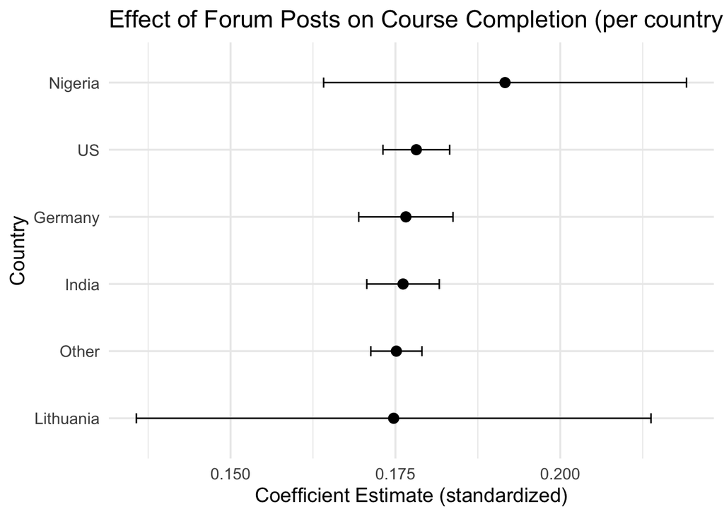

```r
# Visualization with 95% CI
forum_coefs %>%
  mutate(
    lower = estimate - 1.96 * se,
    upper = estimate + 1.96 * se
  ) %>%
  ggplot(aes(x = reorder(country, estimate), y = estimate)) +
  geom_point(size = 3) +
  geom_errorbar(aes(ymin = lower, ymax = upper), width = 0.15) +
  coord_flip() +
  labs(
    title = "Effect of Forum Posts on Course Completion (per country)",
    x = "Country",
    y = "Coefficient Estimate (standardized)"
  ) +
  theme_minimal(base_size = 14)
```

**Comment:** Across all six countries, the effect of forum posts on course completion is positive. Although the magnitude varies by country, the estimates consistently suggest that students who contribute more to course forums are more likely to complete the course. As for the running time, fitting times varied substantially across countries. Countries with larger sample sizes (“US”, “India”, “Other”) required more time, whereas small-population countries (“Lithuania”, “Nigeria”) were much faster. This is consistent with the computational cost of fitting mixed-effects models increasing with data set size.

### problem 3-b

```r
t_total <- system.time({

# Split
df_split <- split(df, df$country)

# Pre-standardize per country
df_split <- lapply(df_split, function(d) {
  d$prior_gpa_z     <- as.numeric(scale(d$prior_gpa))
  d$forum_posts_z   <- as.numeric(scale(d$forum_posts))
  d$quiz_attempts_z <- as.numeric(scale(d$quiz_attempts))
  d
})

# Model formula
fml <- completed_course ~ prior_gpa_z + forum_posts_z + quiz_attempts_z +
  (1 | device_type)

# Parallel fit
num_cores <- min(6, detectCores())

model_list_fast <- mclapply(
  df_split,
  function(dsub) glmer(
    fml,
    data = dsub,
    family = binomial(),
    control = glmerControl(optimizer = "bobyqa")
  ),
  mc.cores = num_cores
)

# Extract coefficients
forum_est_fast <- sapply(model_list_fast, function(m) {
  coef(summary(m))["forum_posts_z", "Estimate"]
})

forum_se_fast <- sapply(model_list_fast, function(m) {
  coef(summary(m))["forum_posts_z", "Std. Error"]
})

})

# report
t_total
```

```
   user  system elapsed
 77.405   8.721  36.875
```

```r
forum_est_fast
```

```
  Germany     India Lithuania   Nigeria     Other        US
0.1765866 0.1761595 0.1747339 0.1916260 0.1751439 0.1781708
```

```r
forum_se_fast
```

```
    Germany       India   Lithuania     Nigeria       Other          US
0.003646527 0.002804819 0.019908576 0.014035949 0.001978449 0.002580357
```

**Comment:** To reduce the total running time of the script, I implemented two key optimizations: Pre-splitting the dataset by country & Pre-standardizing predictors within each country

Instead of calling `filter(country == ...)` inside each model fit, I split the full dataset once at the beginning using `split(df, df$country)`. This avoids repeating a large, expensive filtering operation six times. At the same time, For each country subset, I computed standardized predictors (prior_gpa_z, forum_posts_z, quiz_attempts_z) only once. In addition, I further reduced runtime by running the six country-specific glmer models in parallel using mclapply with 6 cores.

## Problem 4

### load ATP Matches data

```r
library(data.table)
ATP <- fread("https://raw.githubusercontent.com/JeffSackmann/tennis_atp/refs/heads/master/atp_matches_2019.csv")
```

### problem 4-a

In the ATP Matches dataset, the Davis Cup is recorded differently from regular ATP tournaments. Each Davis Cup tie (e.g., France vs Japan, Spain vs Russia) is assigned its own tourney_id. This means that if we simply count distinct(tourney_id), the Davis Cup will appear as many separate tournaments, which would artificially inflate the number of tournaments in 2019.

To address this, we need to group all tourney_id values that belong to the Davis Cup (those containing “2019-M-DC”) and treat them as one single tournament. For the rest of the tournaments, we can safely count distinct tourney_id values directly.

Thus, the total number of tournaments in 2019 is calculated as:

Number of tournaments = distinct non–Davis Cup tourney_ids + 1 (for Davis Cup)

```r
# Split into Davis Cup vs others
davis_ids <- unique(ATP[like(tourney_id, "2019-M-DC"), tourney_id])
other_ids  <- unique(ATP[!like(tourney_id, "2019-M-DC"), tourney_id])

# Final tournament count: all others + 1 for Davis Cup
n_tournaments <- length(other_ids) + 1

n_tournaments
```

```
[1] 69
```

**Answer:** There are 69 tournaments took place in 2019

### problem 4-b

The Laver Cup (tournament_id: 2019-9210) is a special team exhibition event (Team Europe vs Team World). Unlike standard ATP tournaments, it does not have a single final match (round == “F”) that produces an individual player champion. Also, the Davis Cup is a national team competition, not an individual tournament, which means the winner is the nation’s team, not an individual player. Instead, the winner is a team, determined by cumulative points across multiple singles and doubles matches.

Therefore, for Question 2-b (counting how many players won multiple tournaments and identifying the player(s) with the most titles), the Laver Cup and The Davis Cup should be excluded from the statistics.

```r
# Exclude Davis Cup and Laver Cup
ATP_clean <- ATP[!like(tourney_id, "2019-M-DC") & tourney_id != "2019-9210"]

# Tournament winners (Final round winners)
tourney_winners <- unique(
  ATP_clean[round == "F", .(tourney_id, tourney_name, winner_id, winner_name)]
)

# Count titles per player
player_titles <- tourney_winners[, .(num_titles = .N), by = .(winner_id, winner_name)]

# Players with > 1 title
multiple_winners <- player_titles[num_titles > 1]

# display results
n_players_multiple <- nrow(multiple_winners)
max_titles <- max(player_titles$num_titles)

# display results
n_players_multiple
```

```
[1] 12
```

```r
max_titles
```

```
[1] 5
```

**Answer:** There are 12 players won more than one tournament, and the most winning player won 5 tournaments.

### problem 4-c

```r
# Summarize mean and median aces
aces_summary <- ATP[, .(
  mean_winner_aces  = base::mean(w_ace, na.rm = TRUE),
  mean_loser_aces   = base::mean(l_ace, na.rm = TRUE),
  median_winner_aces = stats::median(w_ace, na.rm = TRUE),
  median_loser_aces  = stats::median(l_ace, na.rm = TRUE)
)]

print(aces_summary)
```

```
   mean_winner_aces mean_loser_aces median_winner_aces median_loser_aces
              <num>           <num>              <num>             <num>
1:         7.497402        5.792502                  6                 4
```

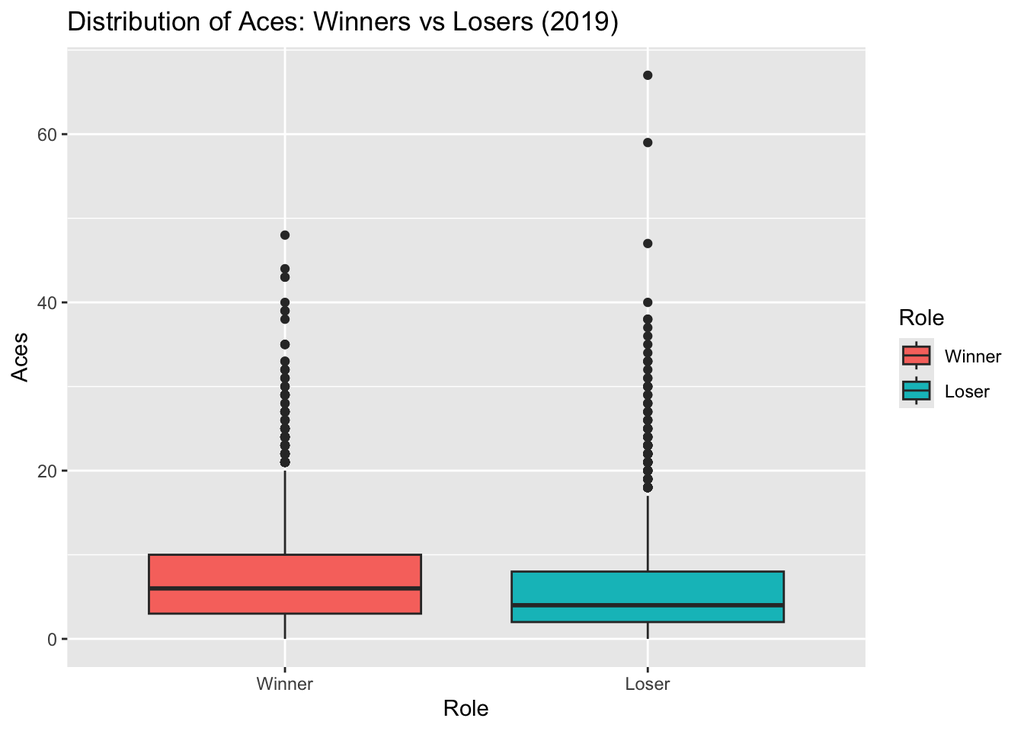

```r
# reshape long
aces_long <- melt(
  ATP[, .(Winner = w_ace, Loser = l_ace)],
  measure.vars = c("Winner", "Loser"),
  variable.name = "Role",
  value.name = "Aces"
)

library(ggplot2)
ggplot(aces_long, aes(x = Role, y = Aces, fill = Role)) +
  geom_boxplot(na.rm = TRUE) +
  labs(title = "Distribution of Aces: Winners vs Losers (2019)")
```

**Answer:** There is clear descriptive evidence that match winners tend to serve more aces than losers in 2019. While not a formal hypothesis test, the mean, median, and distribution comparisons all point in the same direction.

### problem 4-d

For each player, the win rate = number of matches won / total matches played

```r
# Wins per player
wins <- ATP[, .(wins = .N), by = winner_name]

# Losses per player
losses <- ATP[, .(losses = .N), by = loser_name]

# merge wins & losses (full join)
player_stats <- merge(wins, losses,
                      by.x = "winner_name", by.y = "loser_name",
                      all = TRUE)

# rename + compute stats
player_stats[, player := winner_name]
player_stats[, winner_name := NULL]

player_stats[is.na(wins), wins := 0]
player_stats[is.na(losses), losses := 0]

player_stats[, total := wins + losses]
player_stats[, win_rate := wins / total]

player_stats <- player_stats[total >= 5]

# top players
top_players <- player_stats[win_rate == max(win_rate, na.rm = TRUE)]

top_players
```

```
    wins losses       player total  win_rate
   <int>  <int>       <char> <int>     <num>
1:    60      9 Rafael Nadal    69 0.8695652
```

**Answer:** As a result Rafael Nadal has the highest win-rate in tournament 2019.